# snRNA-seq workflow: bioconductor

Saskia Freytag

08/04/2019

## Prerequisities

### Required libraries

```r
library(DropletUtils)
library(scater)
library(scran)
library(umap)
```

```r
library(ggplot2)
theme_set(theme_classic())
```

## Import data

### Loading data

Unfortunately, Cell Ranger recently changed its naming convention. The file that used to be called `genes.tsv` is now named `features.tsv`. The easiest work-around, until a change to `DropUtils`, is to rename the files.

```r
samples <- list.files(here::here("data/raw"))
dat <- lapply(samples, function(x) read10xCounts(here::here("data/raw", x)))
```

## Filtering

### Filtering of nuclei

First, we filter any nuclei with greater than 5% total mitochondrial contamination. Fortunatley, there are no nuclei in this test dataset. But this is an importnat quality control step.

```r
for (i in 1:length(dat)) {

  rowData(dat[[i]])$Mito <-  grepl("^MT-", rowData(dat[[i]])$Symbol)
  dat[[i]] <- calculateQCMetrics(dat[[i]],
    feature_controls=list(Mt=rowData(dat[[i]])$Mito))

}

no_nuclei_mito <- sapply(dat, function(x) sum(colData(x)$pct_counts_Mt>5))

paste0("Nuclei with more than 5% mitochondrial percentage in ", samples, ": ",
      no_nuclei_mito, " (", round(no_nuclei_mito/sapply(dat,
        function(x) dim(x)[2]),2)*100, "%)")
```

```
## [1] "Nuclei with more than 5% mitochondrial percentage in v2: 0 (0%)"
## [2] "Nuclei with more than 5% mitochondrial percentage in v3: 0 (0%)"
```

```r
dat <- lapply(dat, function(x) x[,!colData(x)$pct_counts_Mt>5])
```

Next we filter any nuclei that have library sizes three standard below the median. We also filter any nuclei with a number of features three standard deaviations below the median.

```r
libsize_drop <- lapply(dat, function(x)
  isOutlier(x$total_counts, nmads=3, type="lower", log=TRUE))
feature_drop <- lapply(dat, function(x)
  isOutlier(x$total_features_by_counts, nmads=3, type="lower", log=TRUE))

no_nuclei_libsize <- sapply(libsize_drop, function(x) sum(x))
no_nuclei_feature <- sapply(feature_drop, function(x) sum(x))

paste0("Nuclei not passing library size filter ", samples, ": ",
      no_nuclei_libsize, " (", round(no_nuclei_libsize/sapply(dat, function(x) dim(x)[2]),2)*100, "%)")
```

```
## [1] "Nuclei not passing library size filter v2: 0 (0%)"
## [2] "Nuclei not passing library size filter v3: 53 (4%)"
```

```r
paste0("Nuclei not passing feature filter ", samples, ": ",
      no_nuclei_feature, " (", round(no_nuclei_feature/sapply(dat, function(x) dim(x)[2]),2)*100, "%)")
```

```
## [1] "Nuclei not passing feature filter v2: 47 (4%)"
## [2] "Nuclei not passing feature filter v3: 141 (11%)"
```

```r
for (i in 1:length(samples)){

  dat[[i]] <- dat[[i]][, !libsize_drop[[i]]|feature_drop[[i]]]

}
```

### Filtering of genes

In order to filter genes we need to combine the data. Then we filter any gene that is seen in less than 1% of the data.

```r
sce_counts <- Reduce(cbind, lapply(dat, function(x) counts(x)))

keep_genes <- apply(sce_counts, 1, function(x)
  sum(x>0)>(dim(sce_counts)[2]*0.01))

dat <- lapply(dat, function(x) x[keep_genes,])
sce_counts <- sce_counts[keep_genes,]
```

## Normalization

```r
dat <- do.call(multiBatchNorm, dat)
```

### Batch correction

Perfom mnn correction to generate a common PCA representation for the samples.

```r
dat_pca <- do.call(fastMNN,
  c(dat, list(k=20, d=50, approximate=TRUE)))
```

Next make a new `SingleCellExperiment` object with the combined data. In order to ensure that any cell can be traced first make a new sample identifier.

```r
for (i in 1:length(samples)){

  dat[[i]]$Sample_ID <- samples[i]

}

sce_colData <- Reduce(rbind, lapply(dat, function(x) colData(x)))
sce_rowData <- rowData(dat[[1]])

sce <- SingleCellExperiment(assays=list(counts=sce_counts),
                            colData=sce_colData,
                            rowData=sce_rowData)

rm("sce_counts", "sce_rowData", "sce_colData")
gc()
```

```
##            used  (Mb) gc trigger   (Mb) limit (Mb)  max used   (Mb)
## Ncells  5291893 282.7    8444571  451.0         NA   8007887  427.7
## Vcells 40984023 312.7  173114553 1320.8      16384 270298285 2062.3
```

```r
sce_lib_factors <- c(unlist(sapply(dat, function(x) librarySizeFactors(x))))
sce@int_colData$size_factor <- sce_lib_factors
sce <- normalize(sce)
reducedDim(sce, "MNN") <- dat_pca$corrected
```

Let’s see whether this has improved things.

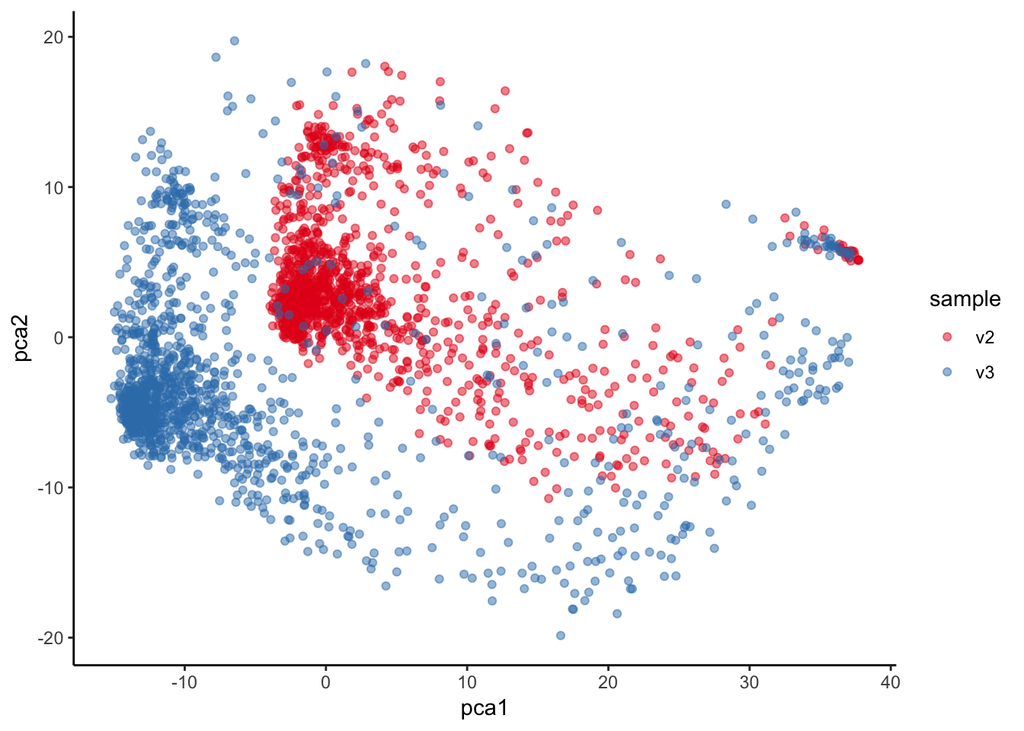

```r
sce <- runPCA(sce)

plot_dat <- data.frame(pca1 = reducedDim(sce, "PCA")[,1],
                       pca2 = reducedDim(sce, "PCA")[,2],
                       mnn1 = reducedDim(sce, "MNN")[,1],
                       mnn2 = reducedDim(sce, "MNN")[,2],
                       sample = sce$Sample_ID)

ggplot(plot_dat, aes(x = pca1, y = pca2)) +
  geom_point(aes(col = sample), alpha = 0.5) +
  scale_colour_brewer(palette = "Set1")
```

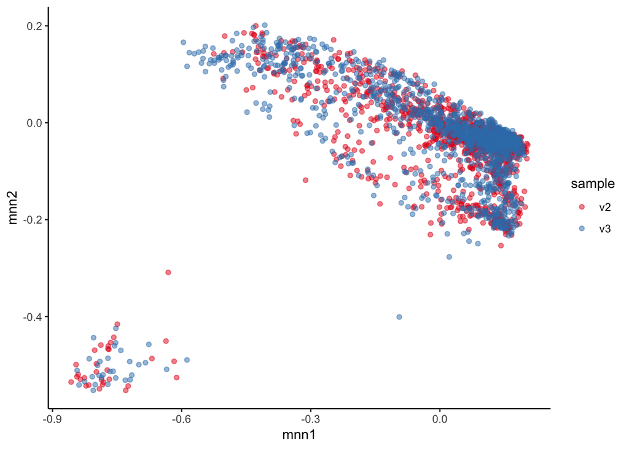

```r
ggplot(plot_dat, aes(x = mnn1, y = mnn2)) +
  geom_point(aes(col = sample), alpha = 0.5) +
  scale_colour_brewer(palette = "Set1")
```

## Clustering

### Dimension Reduction

```r
umap.defaults$n_neighbors = 50
umap.defaults$min_dist= 0.1
sce <- runUMAP(sce, use_dimred="MNN", config = umap.defaults)
```

### Clustering

```r
snn.gr <- buildSNNGraph(sce, use.dimred="UMAP", k=100)
clusters <- igraph::cluster_louvain(snn.gr)
table(clusters$membership, sce$Sample_ID)
```

```
##
##      v2  v3
##   1 108 144
##   2 108  77
##   3 143 210
##   4 214 202
##   5 272 325
##   6 164 167
##   7 197 176
```

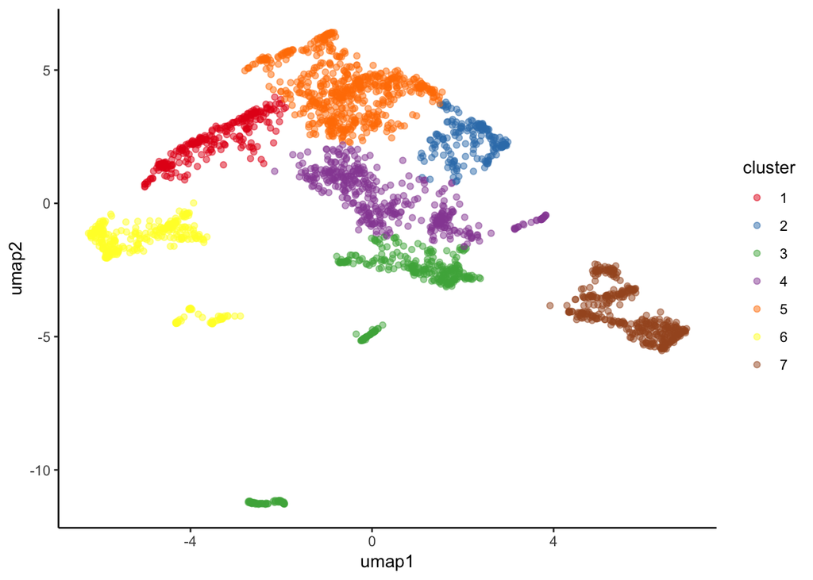

```r
sce$Cluster <- factor(clusters$membership)

plot_dat$umap1 <- reducedDim(sce, "UMAP")[,1]
plot_dat$umap2 <- reducedDim(sce, "UMAP")[,2]
plot_dat$cluster <- sce$Cluster

ggplot(plot_dat, aes(x = umap1, y=umap2)) +
  geom_point(aes(col = cluster), alpha = 0.5) +
  scale_colour_brewer(palette = "Set1")
```

## Annotation

Highlight marker genes for different cell types.

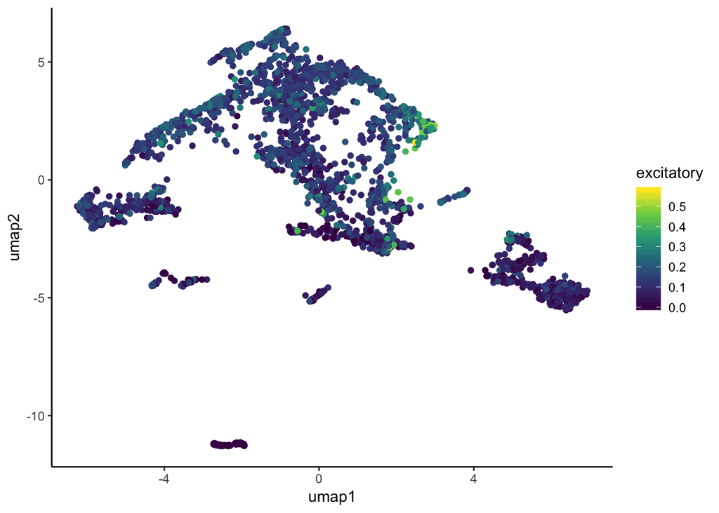

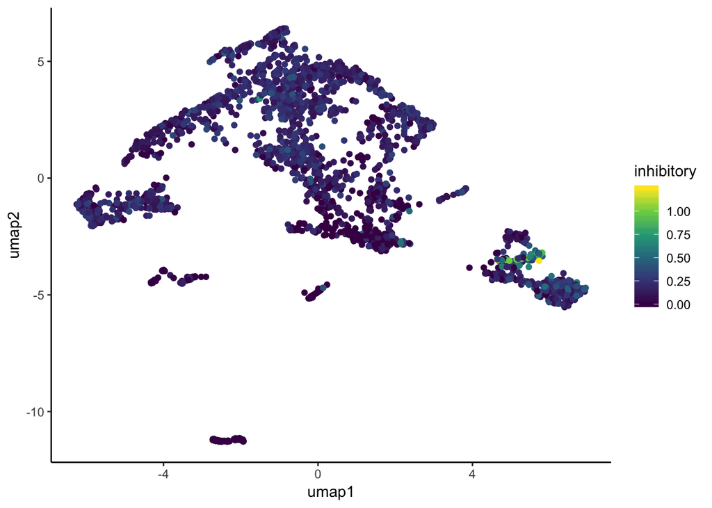

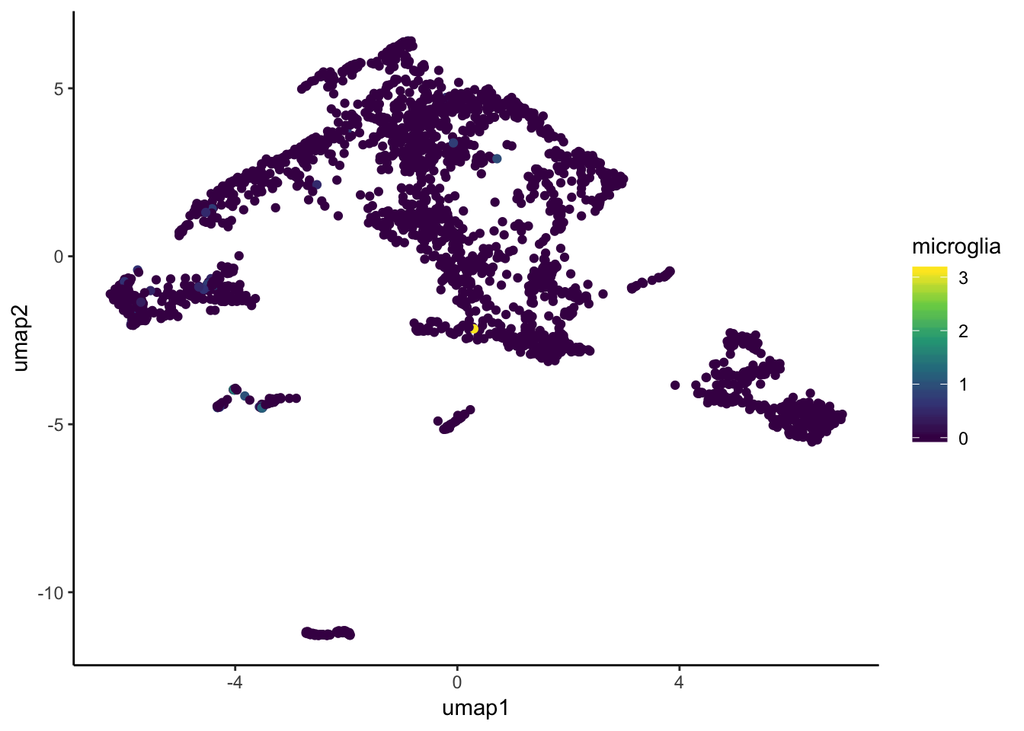

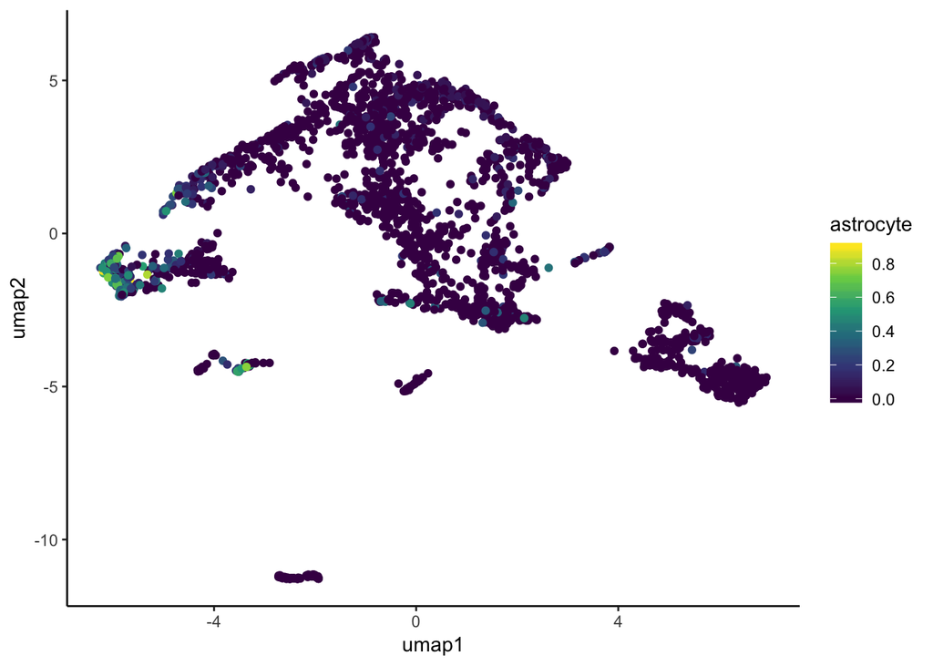

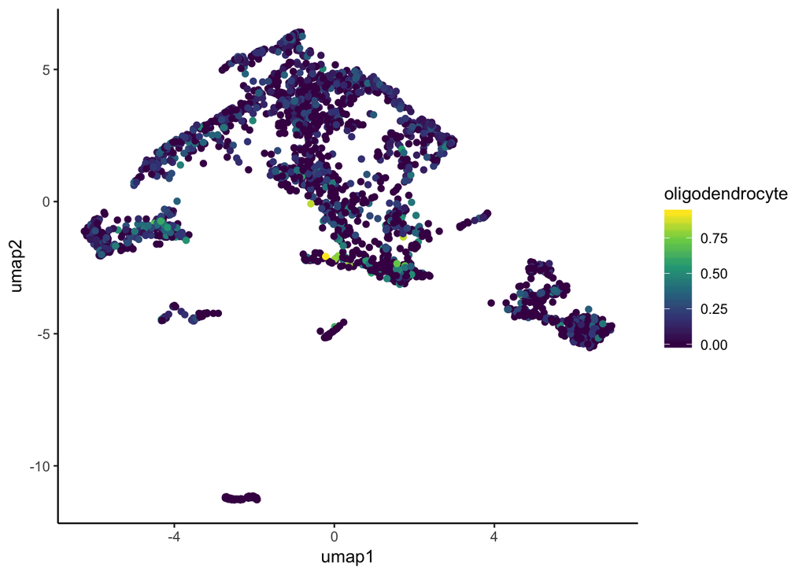

```r
known_markers <- read.table(here::here("data/meta/",
  "mouse_brain_cell_type_markers.txt"), sep="\t", fill=TRUE, header=T)

all_cell_types <- sapply(as.character(known_markers$Description),
  function(x) strsplit(x, ",")[[1]][1])
known_markers$CellType <- all_cell_types

excitatory_markers <- sapply(grep("Excitatory neurons", known_markers$CellType),
  function(x) unlist(strsplit(as.character(known_markers$Markers[x]), " ")))
inhibitory_markers <- sapply(grep("interneurons", known_markers$CellType),
  function(x) unlist(strsplit(as.character(known_markers$Markers[x]), " ")))
microglia_markers <- sapply(grep("Microglia", known_markers$CellType),
  function(x) unlist(strsplit(as.character(known_markers$Markers[x]), " ")))
astrocyte_markers <- sapply(grep("astrocyte", known_markers$CellType),
  function(x) unlist(strsplit(as.character(known_markers$Markers[x]), " ")))
oligo_markers <- sapply(grep("oligodendrocyte", known_markers$CellType),
  function(x) unlist(strsplit(as.character(known_markers$Markers[x]), " ")))

markers <- list(excitatory = unlist(excitatory_markers),
                inhibitory = unlist(inhibitory_markers),
                microglia = unlist(microglia_markers),
                astrocyte = unlist(astrocyte_markers),
                oligodendrocyte = unlist(oligo_markers))

cell_type_means <- sapply(markers, function(x) {
  index <- match(x , rowData(sce)$Symbol)
  index <- index[!is.na(index)]
  return(colMeans(as.matrix(logcounts(sce[index,]))))
})
colnames(cell_type_means) <- names(markers)

plot_dat <- cbind(plot_dat, cell_type_means)

for (i in colnames(cell_type_means)) {

  gg <- ggplot(plot_dat, aes(x = umap1, y = umap2)) +
    geom_point(aes_string(color=i)) + scale_color_viridis_c()

  print(gg)

}
```

## Trajectory analysis

Still to come!